# Comparing different methods to predict pH value in water quality testing data.

**Ting-Shao Chang, Yi-Cheng Lai, & Quentin Lim**

## Introduction

### Water Quality

The pH value is crucial in assessing water quality because it measures the acidity or alkalinity of a solution, influencing the health of aquatic ecosystems. In the context of drinking water, maintaining an optimal pH range is essential to ensure the safety and palatability of the water. In addition, the pH level affects both the chemical reactions in the water and the behavior of pollutants. A balanced pH ensures that water is safe for consumption while preventing corrosion or scaling in pipes, which can release harmful metals into the water supply.

### Drinking Water Safty

Ensuring the safety of drinking water is a critical public health issue. Safe drinking water must be free from harmful contaminants and maintain a stable pH level, which helps prevent the leaching of toxic substances from pipes, such as lead and copper. Furthermore, proper pH levels inhibit the growth of harmful bacteria and viruses, safeguarding the water from biological threats. Regulatory standards and continuous monitoring are vital to maintaining these conditions, ensuring water remains safe and healthy for consumption.

The presence of contaminants like heavy metals, and industrial chemicals can pose serious health risks. For instance, excessive nitrates in drinking water can cause methemoglobinemia, or "blue baby syndrome," which affects the oxygen-carrying capacity of blood in infants. Similarly, long-term exposure to heavy metals such as arsenic, cadmium, and mercury can lead to chronic health issues, including cancer and neurological disorders. Therefore, stringent regulations are necessary to limit the concentration of these hazardous substances in drinking water.

Maintaining an appropriate pH level, typically between 6.5 and 8.5, is essential for minimizing corrosion in the water distribution system. Corrosive water can dissolve metals from pipes and plumbing fixtures, introducing toxic substances into the water supply. Therefore, these risks can be significantly mitigated by controlling the pH of drinking water.

In conclusion, the pH value is crucial for the safety of drinking water. However, the pH value is unknown in some specific cases. Therefore, pH value only could be predicted by considering the related factors in water, such as conductivity and so on. In this study, we propose to consider several predictors and attempt to predict the pH value in water by using many statistical models. Finally, the concept of each model and its results will be further explained based on the exploratory data analysis. According to these experimental results, we expect that the pH value could be predicted accurately and that drinking water safety could be monitored further.

### Dataset

Water Quality Testing (ShreyanshVerma27, 2023)

Main components analyzed:

- pH value
  - pH measures the acidity or basicity of a liquid on a scale from 0 to 14. Values less than 7 indicate acidic conditions, values greater than 7 suggest primary needs and a value of 7 indicates a neutral state.
- Dissolved Oxygen (DO)
  - DO measures the amount of oxygen dissolved in water and is essential for aquatic life. High DO levels are crucial for the survival of fish and other marine organisms.
- Temperature
  - Temperature affects various physical, chemical, and biological processes in water bodies. It is an essential factor that influences the rate of many aquatic processes.
- Turbidity
  - Turbidity measures the cloudiness or haziness of water caused by large numbers of individual particles that are generally invisible to the naked eye, similar to smoke in air. It is a key test of water quality since high turbidity can significantly reduce the biological activity of aquatic plants and organisms.
- Conductivity
  - Conductivity is a measure of water's capability to pass electrical flow. It reflects the level of ions in the water and is used as an indicator of water quality. Higher conductivity indicates higher levels of dissolved solids which may include harmful chemical pollutants or other minerals.

Data Source: https://www.kaggle.com/datasets/shreyanshverma27/water-quality-testing

## Methodology & Results

[figure not shown]

Second, the number of data is 500. In this study, we propose to separate 80% of the data for training and 20% for testing and use Root Mean Square Error (RMSE), Mean Absolute Error (MAE) and R-squared to evaluate the model performance.

- ### Linear Regression Model
  - Multiple Linear regression (MLR) is a linear approach to modeling the relationship between a scalar response variable (also known as the dependent variable or output variable) and one or more predictor variables (a.k.a. independent variables or input variables). The MSE is 0.00379, MAE is 0.04948, and R-squared is 0.60156, indicating this model fits the data well since the dataset itself is not large and is not complex. Thus, using MLR will yield good results.

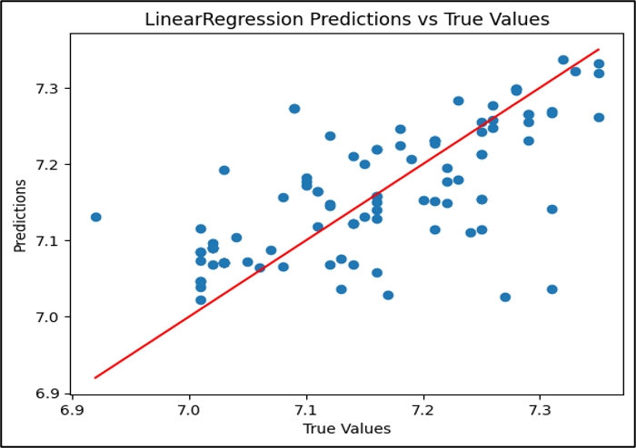

- ### Support Vector Machine (RBF kernel)
  - Support Vector Machine (SVM) is a supervised machine learning algorithm used for classification and regression tasks. It works by finding the optimal hyperplane that best separates different classes in the feature space. SVM aims to maximize the margin, which is the distance between the hyperplane and the nearest data points from each class. This approach allows SVM to achieve high accuracy and robustness, especially in high-dimensional spaces. Additionally, SVM can handle both linear and non-linear data through kernel functions, which map the input data into higher-dimensional spaces where the classes are more easily separable. The MSE is 0.00593, MAE is 0.06453, and R-squared is 0.377. Although the values of MSE and MAE from SVM are slightly larger than those values from MLR, the result is still not bad. The R squared value of 0.377 means that the model can only explain approximately 37.7% of the variance in the target variable. It is also acceptable.

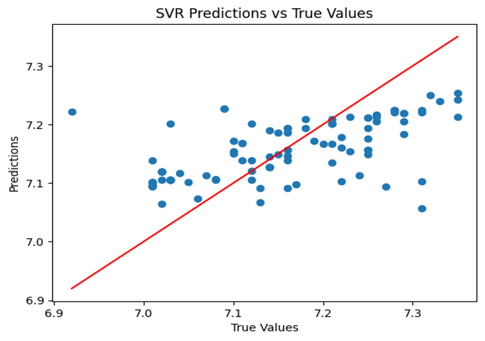

- ### Multi-Linear Perceptron
  - Multi-layer Perceptron (MLP) is a type of artificial neural network (ANN) that consists of multiple layers of nodes, or neurons, organized in a feedforward manner. Each neuron in one layer is connected to every neuron in the next layer. The MLP typically consists of an input layer, one or more hidden layers, and an output layer. In a Multi-Layer Perceptron, each neuron applies a non-linear activation function to the weighted sum of its inputs, transforming the input data into a non-linear form. This enables MLPs to learn complex patterns and relationships in the data. The MSE is 0.01684, the MAE is 0.08941, and the R-squared is -0.76755. R squared value is negative, indicating that the model's ability to explain the variance in the target variable is worse than simply predicting the mean. This may occur when the model performs extremely poorly, such that its predictions are even worse than random guessing using the mean. In such cases, the model may not be suitable for predicting the target variable at all. The suitable application of MLP lies in dealing with more complex data. If the number of training data is not enough, it may easily cause overfitting and degrade the model performance. In our case, the dataset is simple, so we assume that the MLP model is not suitable for applying this case.

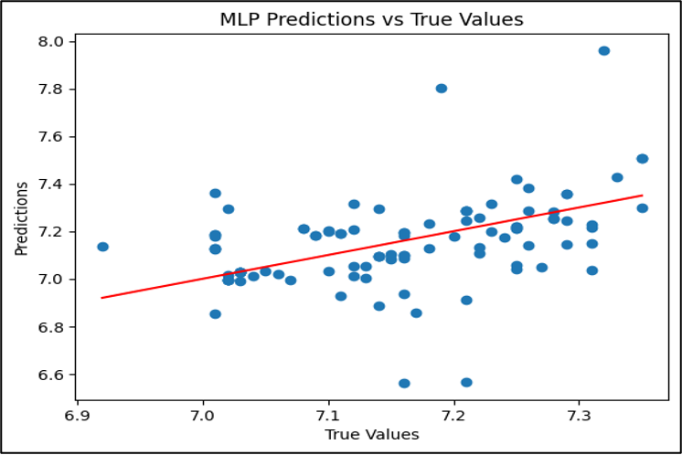

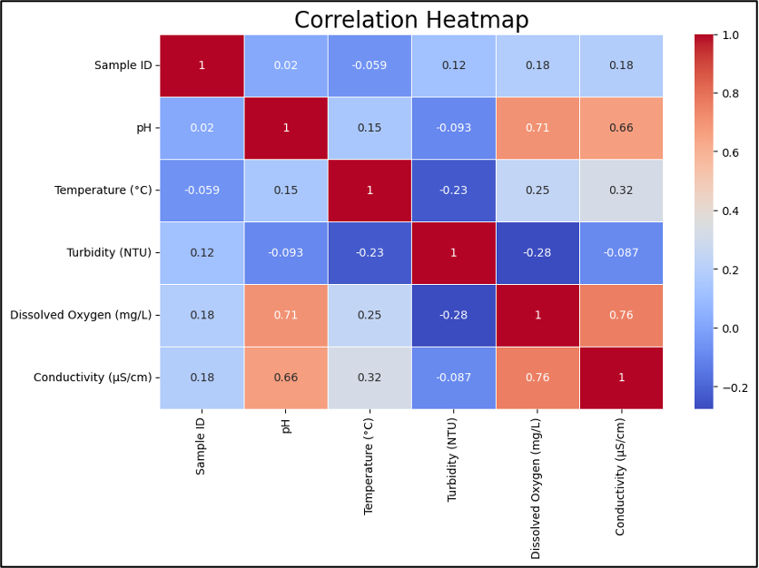

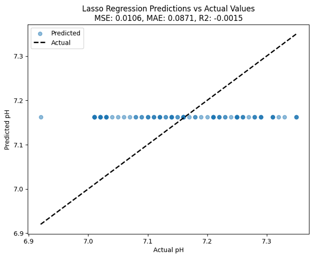

- ### Ridge Regression
  - Ridge Regression is a technique used for linear regression to handle data with multicollinearity. It achieves regularization by adding a penalty term to the traditional least squares cost function. The penalty term in Ridge Regression is the product of the sum of squares of coefficients and a regularization parameter (usually denoted as λ). This penalty term restricts the size of coefficients, thereby reducing the complexity of the model. Generally, Ridge Regression retains all predictor variables but shrinks their coefficients. Thus, it can preserve the features more completely compared with Lasso Regression. The MSE is 0.006, the MAE is 0.0576, and the R-squared is 0.436, indicating good model performance. We assume that the Ridge Regression model retains all predictor variables rather than compressing certain coefficients to zero, so it can fit the data well.

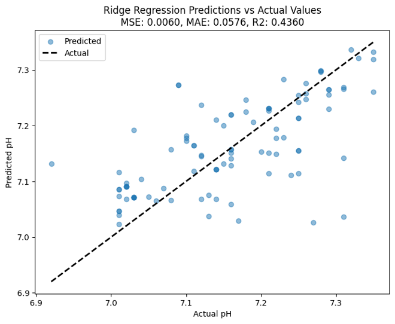

- ### Kernel Ridge Regression

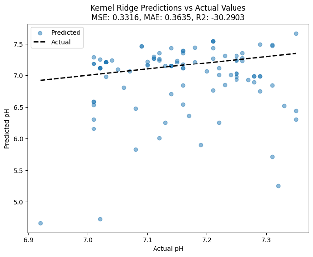

- ### Decision Tree
  - The Decision Tree is a supervised learning algorithm often used for classification and regression tasks. It predicts the target variable's values by learning simple decision rules from the dataset. Starting at the root node, the model splits into sub-nodes, each representing a decision rule based on feature values. This method is valued for its ease of understanding and explanation, with results explainable through simple rules and visual tree structures. However, its simplistic approach might lead to underfitting in complex datasets, as indicated by an R² value of 0.3943.

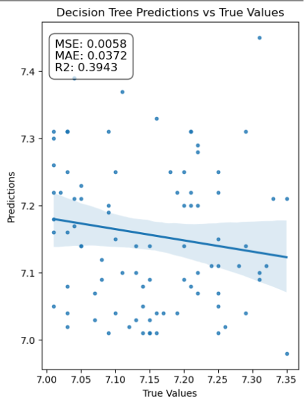

- ### Random Forest
  - Random Forest is a powerful machine learning algorithm, part of the ensemble learning methodology, particularly suited for classification and regression tasks. It consists of multiple decision trees, each trained on random subsets of the dataset and making independent predictions. The final prediction is determined by averaging or majority voting across all trees. This method effectively reduces overfitting, enhancing model stability and accuracy, and achieves a high R² value of 0.7404, making it especially effective for complex and large datasets.

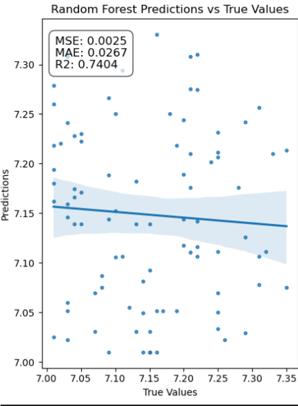

- ### Extra Tree
  - Extra Trees (Extremely Randomized Trees) is an ensemble learning method similar to Random Forest, but it introduces more randomness in the tree-building process. At each decision node, this algorithm randomly selects features and their split thresholds, enhancing model diversity and robustness. This increased randomness helps reduce variance while maintaining or improving the bagging effect among the trees, resulting in a stable R² value of 0.6586. This makes Extra Trees faster to train and often more accurate in various applications.

[figure not shown]

- ### XGBoost
  - XGBoost (eXtreme Gradient Boosting) stands out by implementing a sophisticated version of gradient boosting that optimizes both the model's complexity and training speed. It utilizes advanced techniques such as regularization and tree pruning to refine model training, making it highly efficient and less prone to overfitting. This results in a robust performance with an R² value of 0.5968, enhancing its appeal in various machine learning applications due to its accuracy and computational efficiency.

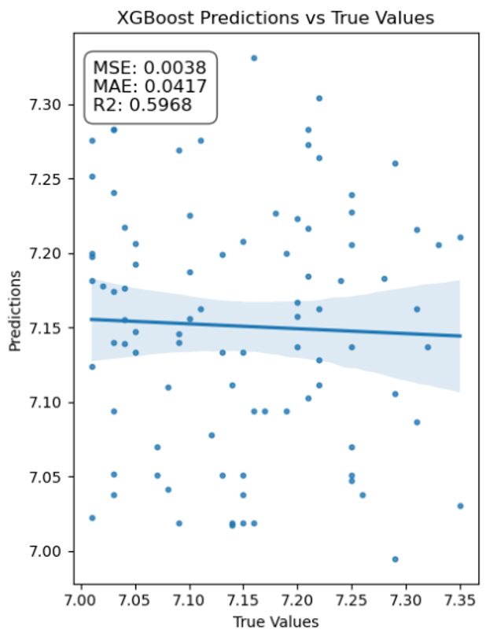

- ### MLP+Bagging
  - MLP + Bagging combines the robustness of bagging with the flexibility of neural networks. By training multiple Multi-Layer Perceptrons (MLPs) on varied subsets of the dataset and averaging their outputs, this method significantly reduces the likelihood of fitting to noise, thereby stabilizing predictions. This approach enhances predictive accuracy and model stability, resulting in a strong R² value of 0.6100. This combination effectively mitigates overfitting and leverages the complex pattern recognition capabilities of neural networks.

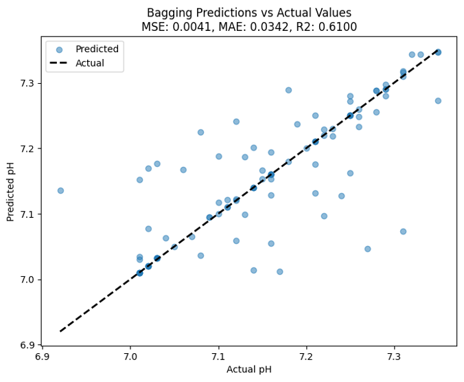

- ### Gradient Boosting
  - Gradient Boosting is a powerful ensemble learning al1gorithm suited for classification and regression tasks. It iteratively trains multiple weak learners (typically decision trees), with each new learner attempting to correct the errors of its predecessor to minimize prediction error. This step-by-step improvement allows the model to effectively handle complex and non-linear data patterns. By optimizing the loss function and sequentially adding new models, Gradient Boosting significantly enhances prediction accuracy. In this analysis, it achieved an R² value of 0.5144, demonstrating reasonable predictive capability.

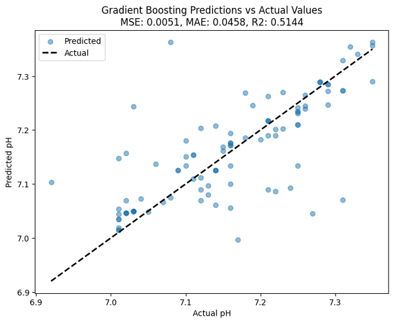

These results emphasize the advantages of ensemble learning methods like Random Forest, Extra Trees, and Bagging in providing more stable and accurate predictions, especially when dealing with environmental data that may involve complex interactions.

## Conclusions

- ### Different models were assessed based on RMSE, MAE, and R-squared values. The effectiveness of models like Multiple Linear Regression, SVM, MLP, Lasso Regression, and Ridge Regression varied, with some models showing more promise than others in terms of accuracy and fit.
- ### The Ridge Regression model performed well with an acceptable balance of model complexity and prediction accuracy. Random Forest and XGBoost also showed strong performance, particularly in handling complex dataset interactions.
- ### Some models, like the MLP and Lasso Regression, did not perform adequately, with MLP showing a negative R-squared value, indicating issues like potential overfitting or insufficient training data.
- ### The study emphasizes the importance of ensemble learning methods such as Random Forest, Extra Trees, and Bagging for achieving more stable and accurate predictions, particularly in environmental datasets that involve complex interactions.

## Discussion

- ### The effectiveness of ensemble methods such as Random Forest and Extra Trees in the analysis suggests a strong preference for these models when dealing with complex and interacting datasets. This may be attributed to their ability to handle high variability and interdependencies within the data, which could otherwise lead to overfitting in less robust models.
- ### The discussion might also address the challenges posed by the dataset’s limited scope, particularly the concentration of pH values around 7. This could significantly affect the predictive performance of models and suggests a need for acquiring a more varied dataset to improve model training and validation outcomes.

## References

1. ShreyanshVerma27 (2023) Water Quality Testing https://www.kaggle.com/datasets/shreyanshverma27/water-quality-testing
2. Hsieh, W. (2023). Introduction to Environmental Data Science. Cambridge: Cambridge University Press. doi:10.1017/9781107588493